# Quiz 1 Question 2

Wilmer Uruchi

11/2/2018

Activate Library:

```r
library(RcmdrMisc)
library(dplyr)
```

```r
library(ggplot2)
library("lmtest")
library(FactoMineR)
```

First, we generate some populations:

```r
Norm_v1 = rnorm(200, mean = 0, sd = 1)
Norm_v2 = rnorm(200, mean = 10, sd = 1)
Norm_v3 = rnorm(200, mean = 3, sd = 1)
```

Then, we make a quick data transformation:

```r
Norm_v1n=data.frame(x1=Norm_v1, x2="v1")
Norm_v2n=data.frame(x1=Norm_v2, x2="v2")
Norm_v3n=data.frame(x1=Norm_v3, x2="v3")
```

Then, we merge the data:

```r
data=mergeRows(Norm_v1n, Norm_v2n, common.only=FALSE)
data=mergeRows(as.data.frame(data), Norm_v3n, common.only=FALSE)
```

Now we proceed to apply the ANOVA test, so. Let’s begin by checking the necessary asumptions:

- *The observations are independent within and across groups*: Given the fact that we used a r function to generate a random normal distribution, we can assueme independence.
- *The data within each group are nearly normal*: Taken from the previous point. However, let’s visualize the distribution of the samples:

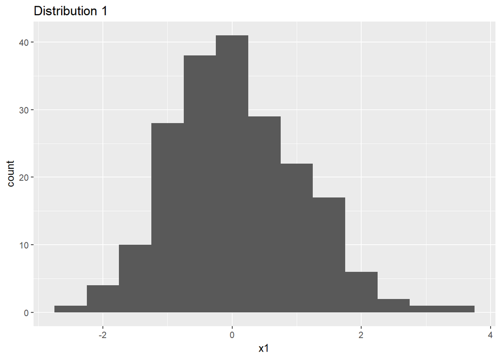

```r
ggplot(data = Norm_v1n, aes(x = x1)) +
  geom_histogram(binwidth = 0.5) +
  ggtitle("Distribution 1")
```

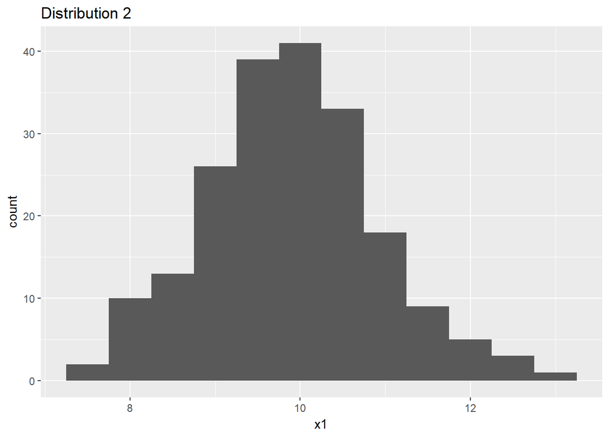

```r
ggplot(data = Norm_v2n, aes(x = x1)) +
  geom_histogram(binwidth = 0.5) +
  ggtitle("Distribution 2")
```

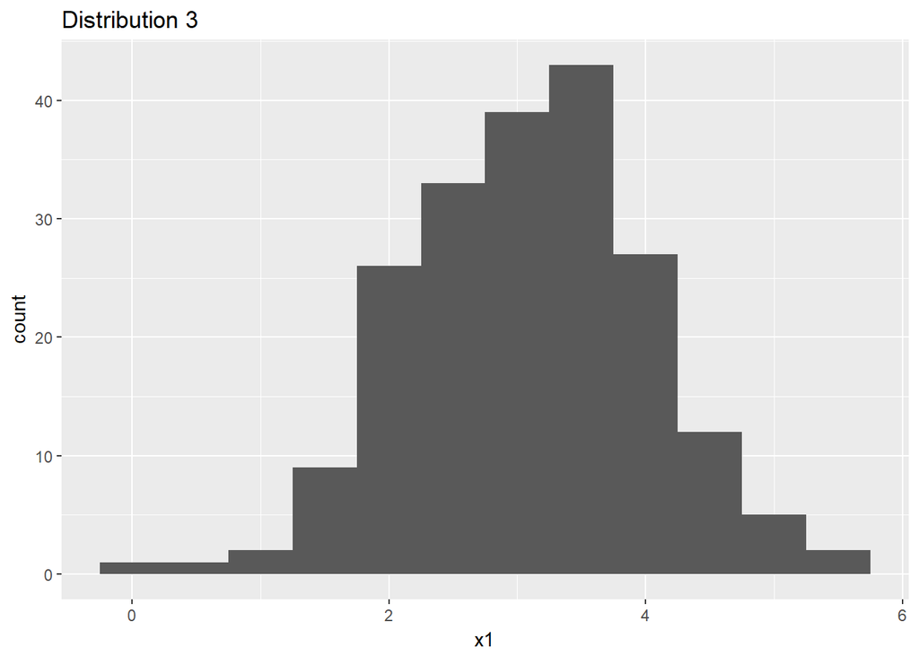

```r
ggplot(data = Norm_v3n, aes(x = x1)) +
  geom_histogram(binwidth = 0.5) +
  ggtitle("Distribution 3")
```

- *The variability across groups is about equal*: Using a standard deviation of 1 in the function we can assume that the variability across the groups is nearly equal.

Perform the ANOVA test:

```r
AnovaModel.1 <- aov(x1 ~ x2, data=data)
summary(AnovaModel.1)
```

```
##              Df Sum Sq Mean Sq F value Pr(>F)
## x2            2  10088    5044    5223 <2e-16 ***
## Residuals   597    577       1
## ---
## Signif. codes:  0 '***' 0.001 '**' 0.01 '*' 0.05 '.' 0.1 ' ' 1
```

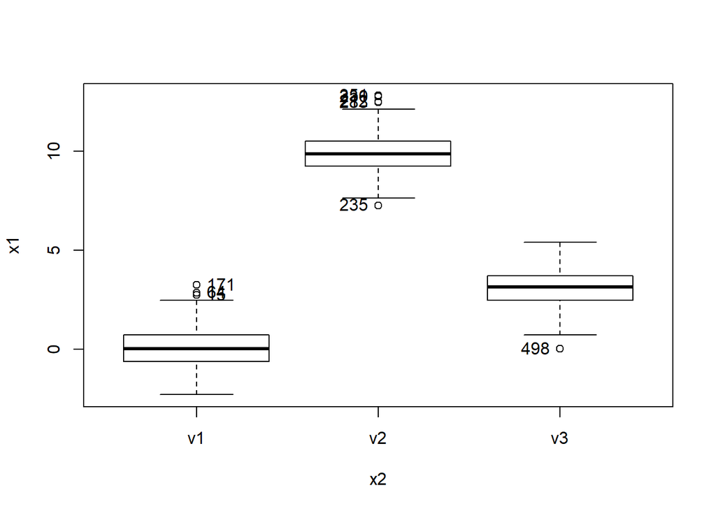

```
## [1] "15"  "64"  "171" "235" "212" "230" "283" "351" "498"
```

```r
Boxplot(x1~x2, data=data, id.method="y")
```

The p-value is less than the alpha = 0.05 so we reject the null hypothesis that says that the mean outcome is the same across all samples.

Testing assumptions:

*Shapiro Test:* The populations from which the samples are selected must be normal:

```r
shapiro.test(residuals(AnovaModel.1))
```

```
##
##  Shapiro-Wilk normality test
##
## data:  residuals(AnovaModel.1)
## W = 0.99748, p-value = 0.5005
```

Given p-value > 0.05, the alternative hypothesis (samples not normally distruted) is rejected.

*Durbin Watson:* The observations within each sample must be independent.

```r
dwtest(AnovaModel.1, alternative ="two.sided")
```

```
##
##  Durbin-Watson test
##
## data:  AnovaModel.1
## DW = 2.0603, p-value = 0.5108
## alternative hypothesis: true autocorrelation is not 0
```

Given p-value > 0.05, the alternative hypothesis (observations within each sample are not independent) is rejected.

*Breusch Pagan Test:* The populations from which the samples are selected must be equal variances (homogeneity of variance).

```r
lmtest::bptest(AnovaModel.1)
```

```
##
##  studentized Breusch-Pagan test
##
## data:  AnovaModel.1
## BP = 2.4748, df = 2, p-value = 0.2901
```

Given p-value > 0.05, the alternative hypothesis (variances are not equal) is rejected.

On the dataset contained on FactoMiner package named decathlon, we want to analyze if both competitions achieve different results in the different disciplines analyzed.

```r
data(decathlon, package="FactoMineR")
```